# Time Series HW9

B082040005 高念慈

2023-04-25

## 2.

Consider the monthly simple returns of the Decile 1, Decile 2, Decile  
9, and Decile 10 of NYSE/AMEX/NASDAQ (紐約證券交易所/美國證券交易所/納斯達克)  
based on market capitalization (市值). The data span is from January 1970 to December 2008,  
and the data are obtained from CRSP.

```r
data2 = read.table("C:/Users/user/Desktop/time_series/HW/m-deciles08.txt", header=T)
head(data2)
```

```
##       date   CAP1RET   CAP2RET   CAP9RET  CAP10RET
## 1 19700130  0.054383 -0.004338 -0.073082 -0.076874
## 2 19700227  0.020264  0.020155  0.064185  0.059512
## 3 19700331 -0.031790 -0.028090 -0.004034 -0.001327
## 4 19700430 -0.184775 -0.193004 -0.115825 -0.091112
## 5 19700529 -0.088189 -0.085342 -0.085565 -0.053193
## 6 19700630 -0.059476 -0.085212 -0.046605 -0.048133
```

### (a)

For the return series of Decile 2 and Decile 10, test the null hypothesis  
that the first 12 lags of autocorrelations are zero at the 5% level.  
Draw your conclusion.

```r
Decile_2 = data2[,3]
Box.test(Decile_2,lag=12,type="Ljung-Box")
```

```
##
##  Box-Ljung test
##
## data:  Decile_2
## X-squared = 55.736, df = 12, p-value = 1.335e-07
```

According to the p-value < 0.05 ,  
we reject the H0 is such that the first 12 lags of Decile_2 autocorrelations  
have some nonzero terms .(Thus, the time series of Decile_2 is not a white noise.)

```r
Decile_10 = data2[,5]
Box.test(Decile_10,lag = 12,type = "Ljung-Box")
```

```
##
##  Box-Ljung test
##
## data:  Decile_10
## X-squared = 10.687, df = 12, p-value = 0.5559
```

According to the p-value > 0.05 , we accept the null hypothesis  
the first 12 lags of Decile_10 autocorrelations are zero.  
(Considered as white noise process)

### (b)

Build an ARMA model for the return series of Decile 2. Perform(執行) model  
checking and write down the fitted model.

```r
ts_Decile_2 = ts(Decile_2,frequency=12,start=c(1970,1))
model1 = ar(ts_Decile_2,method = "mle")
model1$order
```

```
## [1] 12
```

```r
m1 = arima(ts_Decile_2,order = c(12,0,0))
phi_0 = (1-sum(m1$coef[1:12]))*mean(Decile_2)
phi_0
```

```
## [1] 0.008135085
```

```r
round(m1$coef,5)
```

```
##       ar1       ar2       ar3       ar4       ar5       ar6       ar7       ar8
##   0.21028  -0.07803  -0.03588   0.00285  -0.04375  -0.00239   0.00262  -0.07878
##       ar9      ar10      ar11      ar12 intercept
##  -0.01953   0.06895  -0.04536   0.24471   0.01023
```

```r
m1$sigma2
```

```
## [1] 0.003770542
```

# residual 沒檢定

### (c)

Use the fitted ARMA model to produce 1-to 12-step-ahead forecasts of the  
series and the associated standard errors of forecasts.

```r
forecast2 = predict(m1,n.ahead = 12)
forecast2
```

```
## $pred
##                Jan           Feb           Mar           Apr           May
## 2009  1.101801e-02  2.168344e-02  1.827985e-02  1.625908e-02  2.740593e-02
##                Jun           Jul           Aug           Sep           Oct
## 2009  1.615496e-02 -1.313376e-03  2.565188e-03 -2.745673e-02 -2.918551e-02
##                Nov           Dec
## 2009 -2.501148e-02 -5.641547e-05
##
## $se
##             Jan        Feb        Mar        Apr        May        Jun
## 2009 0.06140474 0.06274765 0.06278199 0.06288786 0.06289420 0.06294301
##             Jul        Aug        Sep        Oct        Nov        Dec
## 2009 0.06295157 0.06295195 0.06310736 0.06318306 0.06330522 0.06330589
```

## 3.

Consider the monthly log returns of CRSP equal-weighted index from  
January 1962 to December 1999 for 456 observations. You may obtain  
the data from CRSP directly or from the file m- ew6299.txt on the Web.

```r
data_mew6299 = read.table('https://faculty.chicagobooth.edu/-/media/faculty/ruey-s-tsay/teaching/fts3/m-ew6299.txt')
head(data_mew6299)
```

```
##        V1
## 1  -0.792
## 2   1.532
## 3  -0.596
## 4  -7.049
## 5 -10.319
## 6  -8.880
```

```r
library(TSA)
eacf(data_mew6299[,1])
```

```
## AR/MA
##   0 1 2 3 4 5 6 7 8 9 10 11 12 13
## 0 x o o o o o o x o o o  x  o  o
## 1 x o o o o o o x o o o  x  o  o
## 2 x o o o o o o x o o o  o  o  o
## 3 x x o o o o o o o o o  o  o  o
## 4 x o o o o o o o o o o  o  o  o
## 5 x o x o o o o o o o o  o  o  o
## 6 x x x o o o o o o o o  o  o  o
## 7 x x o x o x x o o o o  o  o  o
```

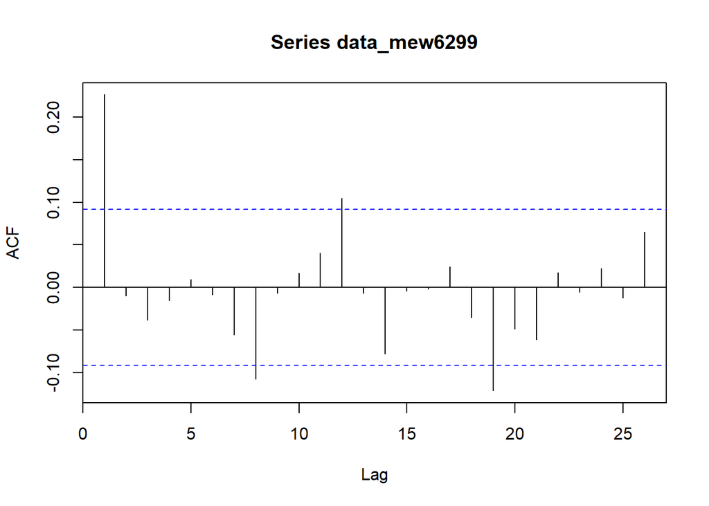

```r
acf(data_mew6299)
```

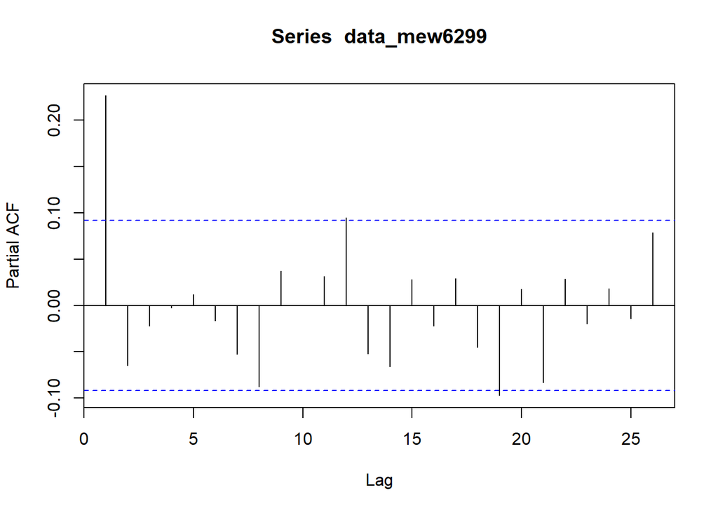

```r
pacf(data_mew6299)
```

### (a)

Build an AR model for the series and check the fitted model.

```r
m4=ar(data_mew6299[,1],method = "mle")
m4$order
```

```
## [1] 1
```

```r
model3 = arima(data_mew6299[,1],order=c(1,0,0))
model3
```

```
##
## Call:
## arima(x = data_mew6299[, 1], order = c(1, 0, 0))
##
## Coefficients:
##          ar1  intercept
##       0.2267     1.0626
## s.e.  0.0456     0.3297
##
## sigma^2 estimated as 29.68:  log likelihood = -1420.11,  aic = 2844.22
```

```r
phi_0 = (1-sum(model3$coef[1]))*1.0626
rbind(phi_0=phi_0) # phi_0 as the intercept of AR(1) model
```

```
##            [,1]
## phi_0 0.8217582
```

```r
rbind(sigma_a = sqrt(model3$sigma2))
```

```
##             [,1]
## sigma_a 5.448175
```

- $AR(1)\; model : rt = 0.8218 + 0.2267rt−1 + at, σa = 5.448$

### (b)

Build an MA model for the series and check the fitted model.

```r
model4 = arima(data_mew6299[,1],order=c(0,0,1))
model4
```

```
##
## Call:
## arima(x = data_mew6299[, 1], order = c(0, 0, 1))
##
## Coefficients:
##          ma1  intercept
##       0.2385     1.0605
## s.e.  0.0449     0.3153
##
## sigma^2 estimated as 29.59:  log likelihood = -1419.37,  aic = 2842.73
```

```r
rbind(sigma_a=sqrt(model4$sigma2))
```

```
##             [,1]
## sigma_a 5.439245
```

- $MA(1) \; model : rt = 1.0605 + at + 0.2385at−1 , σa = 5.439$

### (c)

Compute 1- and 2-step-ahead forecasts of the AR and MA models built in the previous two questions.

- $AR(1)$

```r
forecast1=predict(model3,n.ahead = 2)
forecast1
```

```
## $pred
## Time Series:
## Start = 457
## End = 458
## Frequency = 1
## [1] 2.601682 1.411453
##
## $se
## Time Series:
## Start = 457
## End = 458
## Frequency = 1
## [1] 5.448175 5.586364
```

- $MA(1)$

```r
forecast2=predict(model4,n.ahead = 2)
forecast2
```

```
## $pred
## Time Series:
## Start = 457
## End = 458
## Frequency = 1
## [1] 2.250303 1.060512
##
## $se
## Time Series:
## Start = 457
## End = 458
## Frequency = 1
## [1] 5.439245 5.591797
```

### (d)

Compare the fitted AR and MA models.

$$AR(1)\; model : (1 − 0.2267B)rt = 0.8218
+ at$$
long division

$$∵ \frac{1}{1 − \phi_1 B} = 1 + \phi_1 B
+ \phi_1^2B^2 + \phi_1^3B^3...$$
$$∴
MA \; representation \;of \;AR(1) model = \frac{0.8218}{1 − 0.2267}+
a_t(1 + 0.2267B + 0.2267^2B^2+...)$$

$$= 1.063 + a_t + 0.2267a_{t-1} +
0.0514a_{t-2} + 0.0117a_{t-3} +...$$
$$( MA(1)\; model : rt = 1.0605 + at +
0.2385a_{t−1} , σa = 5.439 )$$

- Thus, AR(1) model and MR(1) model are basically the same
- and equally adequate to the time series of log return of m-ew6299 data.